# 非线性振子热膨胀

2025-11-28

课程代码均在如下 GitHub 仓库开源：https://github.com/GHe0000/scientific-programming-intro

## 目录

- 作业要求
- 简谐情况
  - 理论计算
  - 相空间采样
  - 热膨胀系数
  - 能均分
- $k=1,\alpha=0,\beta=1$
  - 非简谐微扰理论计算
  - 相空间采样
  - 热膨胀系数
  - 能均分
- $k=1,\alpha=2,\beta=1$
  - 相空间采样
  - 热膨胀系数
  - 热平衡位置高温下渐进行为
    - 微扰计算
    - 数值验证
  - 能均分
- 结论
- 参考资料
- 致谢
- 附一：问题
- 附二：学习心得

## 作业要求

- 利用 Metropolis 算法采样与温度为 $T=1$ 的热源接触的简谐振子的相空间. 验证采样结果与理论结果是否一致.
- 对如下两种情况的非线性振子，分布函数会发生什么变化？
  - $k=1,\alpha=0,\beta=1$
  - $k=1,\alpha=2,\beta=1$
- 分别计算简谐振子以及上述两种非线性振子的热膨胀效应，即位移平均值随温度的变化曲线.

## 简谐情况

### 理论计算

系统的能量 $E+K+V$，其中：

- $K=\frac{p^2}{2m}$ 为系统动能.
- $V=\frac{1}{2} kx^2 + \frac 1 3 \alpha x^3 + \frac 1 4 \beta x^4$ 为系统势能.

对于简谐情况，$\alpha=\beta=0$. 系统与温度为 $T$ 的热库接触，令 $\beta_T = \frac{1}{k_B T}$，其中 $k_B$ 是玻尔兹曼常数. 根据统计力学原理，系统处于相空间状态 $(x, p)$ 的概率密度函数 $\rho(x, p)$ 正比于玻尔兹曼因子：

$$ \rho(x, p) = \frac{1}{Z} e^{-\beta_T E} $$

其中 $Z$ 是配分函数.

因此，对于间隙情况，有：

$$ \rho(x, p) = \frac{1}{Z} \exp\left( -\frac{\beta_T p^2}{2m} \right) \cdot \exp\left( -\frac{\beta_T k x^2}{2} \right) $$

我们可以将上面的联合概率密度函数拆成独立的两个概率密度函数：

$$P(x) \propto \exp\left( -\frac{\beta_T k x^2}{2} \right) $$ $$P(p) \propto \exp\left( -\frac{\beta_T p^2}{2m} \right) $$

不难发现，对于 $x$ 和 $p$，其分布都是正态分布的形式. 对比正态分布的形式，易得：

$$ P(x) = \sqrt{\frac{\beta_T k}{2\pi}} \exp\left( -\frac{\beta_T k x^2}{2} \right) $$

$$ P(p) = \sqrt{\frac{\beta_T}{2\pi m}} \exp\left( -\frac{\beta_T p^2}{2m} \right) $$

因此：

- **位置分布**：均值为0，方差为 $\frac{k_B T}{k}$ 的高斯分布
- **动量分布**：均值为0，方差为 $m k_B T$ 的高斯分布

从位置分布中我们容易得到，对于简谐情况，$\langle x \rangle =0$ 与 $T$ 无关，因此其热膨胀系数为 $0$.

同时，我们有：$\langle x^2 \rangle = \frac{k_B T}{k}$ 且 $\langle p^2 \rangle = m k_B T$，因此有如下能均分定理：

- 平均势能： $\langle U \rangle = \frac{1}{2}k \langle x^2 \rangle = \frac{1}{2}k_B T$
- 平均动能： $\langle K \rangle = \frac{1}{2m} \langle p^2 \rangle = \frac{1}{2}k_B T$

### 相空间采样

导入需要的库，并针对 Jupyter Notebook 进行一些设置.

```python
import numpy as np # 数值计算库
import numba as nb # 引入 jit 来加速函数（如果需要）
import sympy as sym # 符号计算库
import matplotlib as mpl
import matplotlib.pyplot as plt # 图像绘制
from matplotlib.backends.backend_agg import FigureCanvasAgg # 设置图像后端用
import ipywidgets as ipw # 交互控件
from IPython.display import display, Math, Latex # 打印数学公式
import time

import matplotlib.animation as animation # 创建动画
from IPython.display import HTML # 动画嵌入
import scipy

# 使用 mathjax 来在 jupyter notebook 显示数学公式
sym.init_printing(use_latex='mathjax')

# 设置 matplotlib 绘制的图像嵌入到 jupyter notebook 的方式
%matplotlib widget

# 一个工具函数，可以让静态图片不经过 widget 直接嵌入 Jupyter notebook
# 这样图片可以直接存到 nb 文件里，而不是需要运行才能显示（类似 inline）
def display_inline(fig):
    fig.set_canvas(FigureCanvasAgg(fig))
    display(fig)
    plt.close(fig) # 释放 fig，减小资源消耗

# 一个工具函数，用于在 Jupyter 中快速实现公式和字符串混合输出
def display_math(*args):
    parts = []
    for a in args:
        if isinstance(a, str):
            parts.append(a)
        else:
            parts.append(sym.latex(a))
    display(Math("".join(parts)))

# 设置 matplotlib 使用的字体，避免出现中文问题
plt.rcParams['font.family'] = ['SimSun', 'Times New Roman']
plt.rcParams['mathtext.fontset'] = 'cm'
# 设置默认坐标轴字体大小
plt.rcParams['axes.labelsize'] = 14

# 设置种子，保证可重复性
np.random.seed(3407)
```

不失一般性，下面所有计算中，我们设玻尔兹曼常数 $k_B=1$. 粒子质量 $m=1$. 弹簧 $k=1$. 根据课堂所介绍的 Metropolis 采样方法，我们容易得到采样函数如下：

```python
@nb.njit(cache=True)
def metropolis_samples_full(T, k, alpha, beta, n_samples, step_size=1.0):
    V = lambda x:0.5 * k * x**2 + (1.0/3.0) * alpha * x**3 + 0.25 * beta * x**4
    K = lambda p: 0.5 * p**2
    H = lambda X: V(X[0]) + K(X[1])
    samples = np.zeros((n_samples, 2))
    beta_T = 1.0 / (1.0*T) # kb = 1
    X = np.zeros(2)
    H_old = H(X)
    for i in range(n_samples):
        X_new = X + np.random.uniform(-step_size, step_size, size=2)
        H_new = H(X_new)
        dH = H_new - H_old
        accept = True if dH <= 0 else (np.random.random() < np.exp(-beta_T * dH))
        if accept:
            X = X_new
            H_old = H_new
        samples[i] = X
    return samples
```

我们对简谐振子进行采样 ($\alpha=\beta=0$)，并统计 $x$ 和 $p$ 的直方图，并和理论推导进行对比.

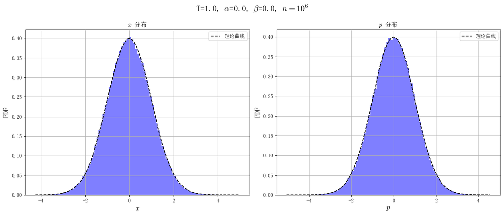

```python
T = 1.0
k = 1.0
alpha = 0.0
beta = 0.0

n_samples = int(1e6)
samples = metropolis_samples_full(T, k, alpha, beta, n_samples)

sigma_x = np.sqrt(T / k)
sigma_p = np.sqrt(T)
x_pdf = lambda x: (1.0 / (sigma_x * np.sqrt(2 * np.pi))) * np.exp(-0.5 * (x / sigma_x)**2)
p_pdf = lambda p: (1.0 / (sigma_p * np.sqrt(2 * np.pi))) * np.exp(-0.5 * (p / sigma_p)**2)

fig, axs = plt.subplots(1, 2, figsize=(14, 6))

axs[0].hist(samples[:, 0], color='blue', alpha=0.5, bins=100, density=True)
x_plt = np.linspace(np.min(samples[:, 0]), np.max(samples[:, 0]), 100)
axs[0].plot(x_plt, x_pdf(x_plt), "k--", label="理论曲线")
axs[0].set_title(r'$x$ 分布')
axs[0].set_xlabel(r'$x$')
axs[0].set_ylabel(r'PDF')
axs[0].legend()
axs[0].grid()

axs[1].hist(samples[:, 1], color='blue', alpha=0.5, bins=100, density=True)
p_plt = np.linspace(np.min(samples[:, 1]), np.max(samples[:, 1]), 100)
axs[1].plot(p_plt, p_pdf(p_plt), "k--", label="理论曲线")
axs[1].set_title(r'$p$ 分布')
axs[1].set_xlabel(r'$p$')
axs[1].set_ylabel(r'PDF')
axs[1].grid()
axs[1].legend()
fig.suptitle(f"T={T}, $\\alpha$={alpha}, $\\beta$={beta}, $n=10^{np.log10(n_samples):.0f}$",fontsize=16)
plt.tight_layout()
display_inline(fig)
```

可以看见，理论和采样模拟完美吻合. 这说明我们的理论推导以及采样模拟是准确的.

进一步，我们还可以通过绘制热力图来可视化相空间中的分布.

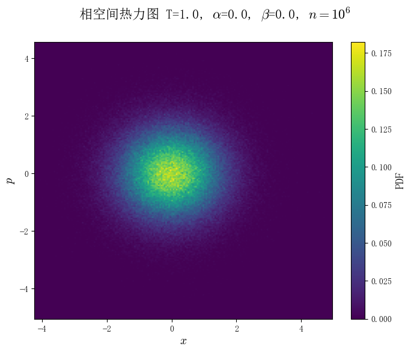

```python
def plot_heatmap(ax, x_data, y_data, bins=200):
    h, xedges, yedges = np.histogram2d(x_data, y_data, bins=bins, density=True)
    im = ax.imshow(h.T,
                   origin='lower',
                   extent=[xedges[0], xedges[-1], yedges[0], yedges[-1]],
                   aspect='auto',
                   cmap='viridis')
    plt.colorbar(im, ax=ax, label="PDF")
    return ax

fig, ax = plt.subplots(figsize=(8, 6))
plot_heatmap(ax, samples[:, 0], samples[:, 1])
fig.suptitle(f"相空间热力图 T={T}, $\\alpha$={alpha}, $\\beta$={beta}, $n=10^{np.log10(n_samples):.0f}$",fontsize=16)
ax.set_xlabel(r'$x$')
ax.set_ylabel(r'$p$')
display_inline(fig)
```

### 热膨胀系数

我们在 $T\in(0,2)$ 之间等间隔取 $200$ 个点，进行采样，每次采样 $n=10^6$，并统计 $\langle x \rangle$. 从而得到下图：

```python
@nb.njit(cache=True)
def metropolis_samples(T, k, alpha, beta, n_samples, step_size=1.0):
    V = lambda x:0.5 * k * x**2 + (1.0/3.0) * alpha * x**3 + 0.25 * beta * x**4
    samples = np.empty(n_samples)
    beta_T = 1.0 / (1.0*T) # kb = 1
    x = 0.0
    V_old = V(x)
    for i in range(n_samples):
        x_new = x + np.random.uniform(-step_size, step_size)
        V_new = V(x_new)
        dV = V_new - V_old
        accept = True if dV <= 0 else (np.random.random() < np.exp(-beta_T * dV))
        if accept:
            x = x_new
            V_old = V_new
        samples[i] = x
    return samples

@nb.njit(cache=True, parallel=True)
def samples_T_arr(T_arr, k, alpha, beta, n_samples, step_size=1.0):
    n_T = len(T_arr)
    ret = np.empty((n_T, n_samples))
    for i in nb.prange(n_T):
        ret[i] = metropolis_samples(T_arr[i], k, alpha, beta, n_samples, step_size)
    return ret
```

```python
T_arr = np.linspace(0.001, 2, 200)
n_samples = int(1e6)
k = 1.0
alpha = 0.0
beta = 0.0

print("编译...")
_ = samples_T_arr(T_arr[:2], k, alpha, beta, n_samples)

print("开始采样...")
t_start = time.time()
samples_arr = samples_T_arr(T_arr, k, alpha, beta, n_samples)
print(f"结束，用时: {time.time() - t_start:.3f} s")
```

```
编译...
开始采样...
结束，用时: 4.102 s
```

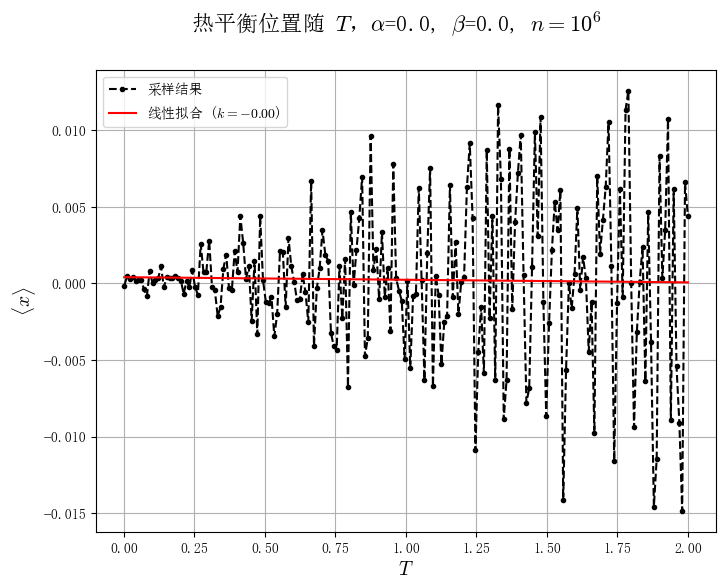

```python
x_avg = np.mean(samples_arr, axis=1)
k, b = np.polyfit(T_arr, x_avg, 1)
fit_y = k * T_arr + b

fig, ax = plt.subplots(figsize=(8,6))
ax.plot(T_arr, x_avg, "k--.", label="采样结果")
ax.plot(T_arr, fit_y, "r", label=f"线性拟合 ($k={k:.2f}$)")
ax.grid()
ax.legend()
ax.set_xlabel("$T$")
ax.set_ylabel(r"$\langle x \rangle$")
fig.suptitle(f"热平衡位置随 $T$，$\\alpha$={alpha}, $\\beta$={beta}, $n=10^{np.log10(n_samples):.0f}$",fontsize=16)
display_inline(fig)
```

可见，虽然 $\langle x \rangle$ 有一定波动，但总体而言，$\langle x \rangle$ 与 $T$ 无关，固定为 $0$. 线性拟合给出的这一点（$k=0.0$）

同时，我们还可以发现，随 $T$ 的增大，$\langle x \rangle$ 波动越来越大，这是合理的，因为随着 $T$ 增大，方差越来越大.

### 能均分

我们从每一次采样中统计动能和势能，得到 $\langle K \rangle$ 和 $\langle V \rangle$ 与 $T$ 的关系：

```python
@nb.njit(cache=True, parallel=True)
def calc_VK(T_arr, k, alpha, beta, n_samples, step_size=1.0):
    n_T = len(T_arr)
    ret = np.empty((n_T, 2))
    for i in nb.prange(n_T):
        ans = metropolis_samples_full(T_arr[i], k, alpha, beta, n_samples, step_size)
        ret[i,0] = 0.5 * np.mean(ans[:,0]**2)
        ret[i,1] = 0.5 * np.mean(ans[:,1]**2)
    return ret
```

```python
T_arr = np.linspace(0.001, 2, 200)
n_samples = int(1e6)
k = 1.0
alpha = 0.0
beta = 0.0

print("编译...")
_ = calc_VK(T_arr[:2], k, alpha, beta, n_samples)

print("开始采样...")
t_start = time.time()
VK_arr = calc_VK(T_arr, k, alpha, beta, n_samples)
print(f"结束，用时: {time.time() - t_start:.3f} s")
```

```
编译...
开始采样...
结束，用时: 21.804 s
```

根勘前面理论，我们有：$\langle K \rangle = \langle V \rangle = \frac 1 2 k_B T$

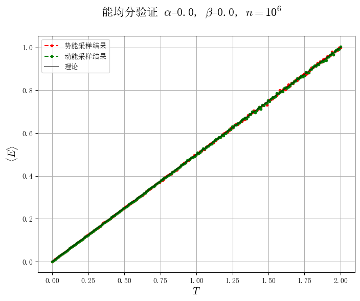

```python
fig, ax = plt.subplots(figsize=(8,6))
ax.plot(T_arr, VK_arr[:,0], "r--.", label="势能采样结果")
ax.plot(T_arr, VK_arr[:,1], "g--.", label="动能采样结果")
ax.plot(T_arr, 0.5 * T_arr, "k-", alpha=0.5, label="理论")
ax.grid()
ax.legend()
ax.set_xlabel("$T$")
ax.set_ylabel(r"$\langle E \rangle$")
fig.suptitle(f"能均分验证 $\\alpha$={alpha}, $\\beta$={beta}, $n=10^{np.log10(n_samples):.0f}$",fontsize=16)
display_inline(fig)
```

可见无论是动能还是势能，其均值和理论 $\frac 1 2 k_B T$ 均吻合. 这和我们前面的推导是相同的.

## $k=1,\alpha=0,\beta=1$

### 非简谐微扰理论计算

下面我们来讨论非简谐的情况. 此时势能为：

$$V=\frac{1}{2} kx^2 + \frac 1 3 \alpha x^3 + \frac 1 4 \beta x^4$$

同样联合概率密度为（$\beta_T = \frac 1 {k_B T}$）：

$$\rho(x,y) = \frac 1 Z \exp(-\beta_T K) \exp(-\beta_T V)$$

因此：

$$P(x) \propto \exp(-\beta_T V)$$ $$P(p) \propto \exp(-\beta_T K)$$

由于 $K$ 在非简谐时和简谐相同，因此我们得到：

$$ P(p) = \sqrt{\frac{\beta_T}{2\pi m}} \exp\left( -\frac{\beta_T p^2}{2m} \right) $$

但对于 $x$，由于 $V$ 发生了变化，因此其分布不再是一个高斯分布. 同时分布也不方便求出. 从而也难以求解出热膨胀系数.

但我们可以通过微扰的方式近似求解热膨胀系数（对应 $T$ 比较小的情况）.

热平均位置 $\langle x \rangle$ 定义为： $$ \langle x \rangle = \frac{\int_{-\infty}^{\infty} x e^{-\beta_{T} E} dx dp}{\int_{-\infty}^{\infty} e^{-\beta_{T} E} dx dp} $$

由于动量积分相同，我们可以约去，因此：

$$ \langle x \rangle = \frac{\int_{-\infty}^{\infty} x e^{-\beta_{T} (\frac{1}{2}kx^2 + \frac{1}{3}\alpha x^3 + \frac{1}{4}\beta x^4)} dx}{\int_{-\infty}^{\infty} e^{-\beta_{T} (\frac{1}{2}kx^2 + \frac{1}{3}\alpha x^3 + \frac{1}{4}\beta x^4)} dx} $$

假设非谐项很小，有：

$$ e^{-\beta_{T} (\frac{1}{3}\alpha x^3 + \frac{1}{4}\beta x^4)} \approx 1 - \beta_{T} \left( \frac{\alpha}{3} x^3 + \frac{\beta}{4} x^4 \right) $$

因此（$Z_0$ 为简谐时的配分函数，$\langle \dots \rangle_0 $ 为简谐时的统计量）：

$$ \begin{aligned} \text{分子} &\approx \int x e^{-\frac{1}{2}\beta_{T} k x^2} \left[ 1 - \beta_{T} \left( \frac{\alpha}{3} x^3 + \frac{\beta}{4} x^4 \right) \right] dx \\ &= - \frac{\beta_{T} \alpha}{3} \cdot \left( Z_0 \langle x^4 \rangle_0 \right) \end{aligned} $$

$$ \begin{aligned} \text{分母} &\approx \int e^{-\frac{1}{2}\beta_{T} k x^2} \left[ 1 - \beta_{T} \left( \frac{\alpha}{3} x^3 + \frac{\beta}{4} x^4 \right) \right]\\ &= Z_0 \left( 1 - \frac{\beta_{T} \beta}{4} \langle x^4 \rangle_0 \right) \\ &\approx Z_0 \end{aligned} $$

因此：

$$ \langle x \rangle \approx - \frac{\alpha}{3 k_B T} \cdot 3 \left( \frac{k_B T}{k} \right)^2 = - \frac{\alpha k_B T}{k^2} $$

### 相空间采样

取 $\alpha=0,\beta=1,T=1$，有

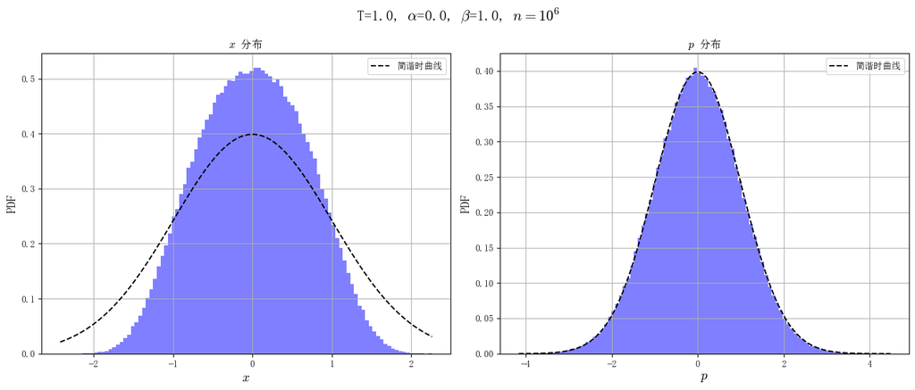

```python
T = 1.0
k = 1.0
alpha = 0.0
beta = 1.0

n_samples = int(1e6)
samples = metropolis_samples_full(T, k, alpha, beta, n_samples)

sigma_x = np.sqrt(T / k)
sigma_p = np.sqrt(T)
x_pdf = lambda x: (1.0 / (sigma_x * np.sqrt(2 * np.pi))) * np.exp(-0.5 * (x / sigma_x)**2)
p_pdf = lambda p: (1.0 / (sigma_p * np.sqrt(2 * np.pi))) * np.exp(-0.5 * (p / sigma_p)**2)

fig, axs = plt.subplots(1, 2, figsize=(14, 6))

axs[0].hist(samples[:, 0], color='blue', alpha=0.5, bins=100, density=True)
x_plt = np.linspace(np.min(samples[:, 0]), np.max(samples[:, 0]), 100)
axs[0].plot(x_plt, x_pdf(x_plt), "k--", label="简谐时曲线")
axs[0].set_title(r'$x$ 分布')
axs[0].set_xlabel(r'$x$')
axs[0].set_ylabel(r'PDF')
axs[0].legend()
axs[0].grid()

axs[1].hist(samples[:, 1], color='blue', alpha=0.5, bins=100, density=True)
p_plt = np.linspace(np.min(samples[:, 1]), np.max(samples[:, 1]), 100)
axs[1].plot(p_plt, p_pdf(p_plt), "k--", label="简谐时曲线")
axs[1].set_title(r'$p$ 分布')
axs[1].set_xlabel(r'$p$')
axs[1].set_ylabel(r'PDF')
axs[1].grid()
axs[1].legend()
fig.suptitle(f"T={T}, $\\alpha$={alpha}, $\\beta$={beta}, $n=10^{np.log10(n_samples):.0f}$",fontsize=16)
plt.tight_layout()
display_inline(fig)
```

可以看到，对于 $\alpha=0,\beta=1$ 的情况，其 $x$ 分布更窄，更集中，但 $p$ 分布和简谐相同，这和我们前面的推导是吻合的，即改变势能形式，不会影响 $p$ 的分布.

同样，我们可以通过热力图可视化相空间分布.

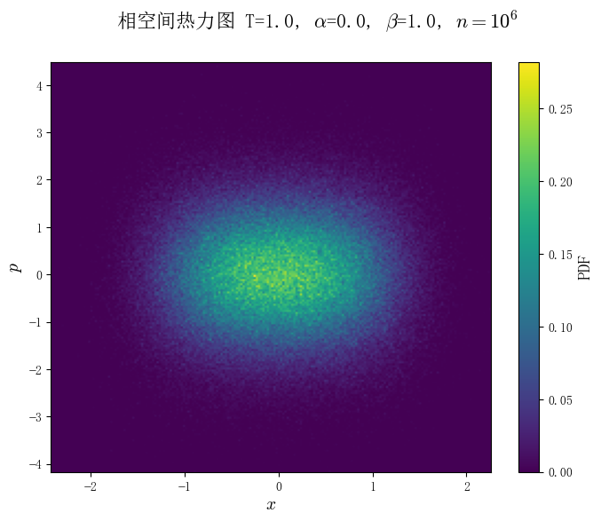

```python
def plot_heatmap(ax, x_data, y_data, bins=200):
    h, xedges, yedges = np.histogram2d(x_data, y_data, bins=bins, density=True)
    im = ax.imshow(h.T,
                   origin='lower',
                   extent=[xedges[0], xedges[-1], yedges[0], yedges[-1]],
                   aspect='auto',
                   cmap='viridis')
    plt.colorbar(im, ax=ax, label="PDF")
    return ax

fig, ax = plt.subplots(figsize=(8, 6))
plot_heatmap(ax, samples[:, 0], samples[:, 1])
fig.suptitle(f"相空间热力图 T={T}, $\\alpha$={alpha}, $\\beta$={beta}, $n=10^{np.log10(n_samples):.0f}$",fontsize=16)
ax.set_xlabel(r'$x$')
ax.set_ylabel(r'$p$')
#ax.set_aspect("equal")
display_inline(fig)
```

### 热膨胀系数

下面我们来计算此时的热膨胀系数.

```python
T_arr = np.linspace(0.001, 2, 200)
n_samples = int(1e6)
k = 1.0
alpha = 0.0
beta = 1.0

print("编译...")
_ = samples_T_arr(T_arr[:2], k, alpha, beta, n_samples)

print("开始采样...")
t_start = time.time()
samples_arr = samples_T_arr(T_arr, k, alpha, beta, n_samples)
print(f"结束，用时: {time.time() - t_start:.3f} s")
```

```
编译...
开始采样...
结束，用时: 4.050 s
```

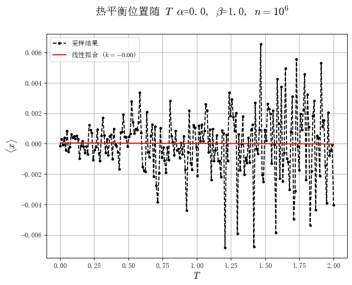

```python
x_avg = np.mean(samples_arr, axis=1)
k, b = np.polyfit(T_arr, x_avg, 1)
fit_y = k * T_arr + b

fig, ax = plt.subplots(figsize=(8,6))
ax.plot(T_arr, x_avg, "k--.", label="采样结果")
ax.plot(T_arr, fit_y, "r", label=f"线性拟合 ($k={k:.2f}$)")
ax.grid()
ax.legend()
ax.set_xlabel("$T$")
ax.set_ylabel(r"$\langle x \rangle$")
fig.suptitle(f"热平衡位置随 $T$ $\\alpha$={alpha}, $\\beta$={beta}, $n=10^{np.log10(n_samples):.0f}$",fontsize=16)
display_inline(fig)
```

根据微扰理论的公式，其热膨胀系数在 $T$ 接近 $0$ 时应该是 $0$. 我们通过数值计算验证：

```python
T_arr = np.linspace(0.001, 0.005, 200)
n_samples = int(1e6)
k = 1.0
alpha = 0.0
beta = 1.0

print("编译...")
_ = samples_T_arr(T_arr[:2], k, alpha, beta, n_samples)

print("开始采样...")
t_start = time.time()
samples_arr = samples_T_arr(T_arr, k, alpha, beta, n_samples)
print(f"结束，用时: {time.time() - t_start:.3f} s")
```

```
编译...
开始采样...
结束，用时: 4.256 s
```

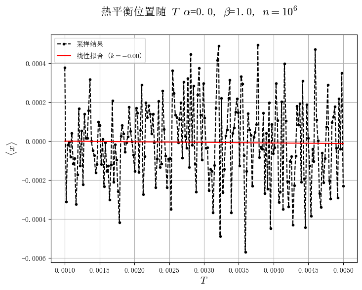

```python
x_avg = np.mean(samples_arr, axis=1)
k, b = np.polyfit(T_arr, x_avg, 1)
fit_y = k * T_arr + b

fig, ax = plt.subplots(figsize=(8,6))
ax.plot(T_arr, x_avg, "k--.", label="采样结果")
ax.plot(T_arr, fit_y, "r", label=f"线性拟合 ($k={k:.2f}$)")
ax.grid()
ax.legend()
ax.set_xlabel("$T$")
ax.set_ylabel(r"$\langle x \rangle$")
fig.suptitle(f"热平衡位置随 $T$ $\\alpha$={alpha}, $\\beta$={beta}, $n=10^{np.log10(n_samples):.0f}$",fontsize=16)
display_inline(fig)
```

可见，在温度很低的情况下，热膨胀系数（对应斜率 $k$）始终为 $0$. 这和我们的微扰理论计算是相吻合的.

### 能均分

下面我们来探索在非线性的情况下是否仍旧有能均分的性质.

```python
@nb.njit(cache=True, parallel=True)
def calc_VK2(T_arr, k, alpha, beta, n_samples, step_size=1.0):
    V = lambda x:0.5 * k * x**2 + (1.0/3.0) * alpha * x**3 + 0.25 * beta * x**4
    K = lambda p: 0.5 * p**2
    n_T = len(T_arr)
    ret = np.empty((n_T, 2))
    for i in nb.prange(n_T):
        ans = metropolis_samples_full(T_arr[i], k, alpha, beta, n_samples, step_size)
        ret[i,0] = np.mean(V(ans[:,0]))
        ret[i,1] = 0.5 * np.mean(ans[:,1]**2)
    return ret
```

```python
T_arr = np.linspace(0.001, 2, 200)
n_samples = int(1e6)
k = 1.0
alpha = 0.0
beta = 1.0

print("编译...")
_ = calc_VK2(T_arr[:2], k, alpha, beta, n_samples)

print("开始采样...")
t_start = time.time()
VK_arr = calc_VK2(T_arr, k, alpha, beta, n_samples)
print(f"结束，用时: {time.time() - t_start:.3f} s")
```

```
编译...
开始采样...
结束，用时: 23.975 s
```

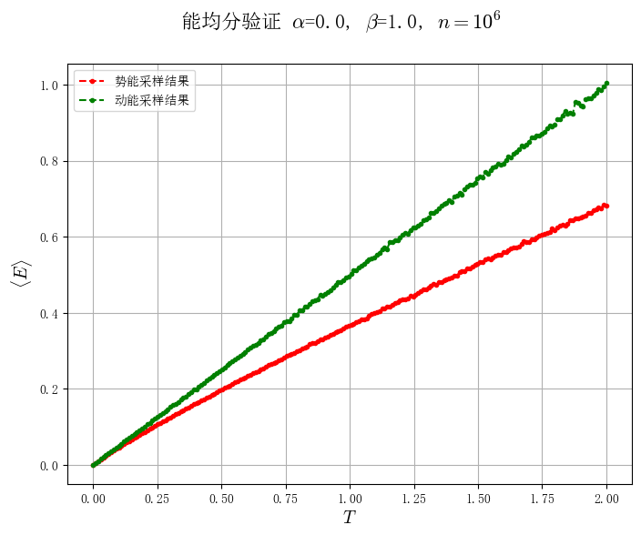

```python
fig, ax = plt.subplots(figsize=(8,6))
ax.plot(T_arr, VK_arr[:,0], "r--.", label="势能采样结果")
ax.plot(T_arr, VK_arr[:,1], "g--.", label="动能采样结果")
#ax.plot(T_arr, 0.5 * T_arr, "k-", alpha=0.5, label="理论")
fit_y = k * T_arr + b
ax.grid()
ax.legend()
ax.set_xlabel("$T$")
ax.set_ylabel(r"$\langle E \rangle$")
fig.suptitle(f"能均分验证 $\\alpha$={alpha}, $\\beta$={beta}, $n=10^{np.log10(n_samples):.0f}$",fontsize=16)
display_inline(fig)
```

可以看见，随着温度增加，动能和势能不再重合，也就是不再出现能均分.

这符合力学中的位力定理，即：

$$ 2 \langle K \rangle = - \left\langle \sum r_i F_i \right\rangle $$

对于 $V\propto r^{-n}$，有：

$$ 2\langle K \rangle = n \langle V \rangle $$

对于简谐，有：

$$ 2\langle K \rangle = 2 \langle V_2 \rangle $$

即能均分. 对于四次方势：

$$ 2\langle K \rangle = 4 \langle V_4 \rangle $$

显然，势能是动能的 $1/2$. 对于此时的系统，同时存在 $V_2$ 和 $V_4$. 因此在低温下仍旧有能均分，高温下势能低于动能.

我们在低温下进行验证：

```python
T_arr = np.linspace(0.001, 0.005, 200)
n_samples = int(1e6)
k = 1.0
alpha = 0.0
beta = 1.0

print("编译...")
_ = calc_VK2(T_arr[:2], k, alpha, beta, n_samples)

print("开始采样...")
t_start = time.time()
VK_arr = calc_VK2(T_arr, k, alpha, beta, n_samples)
print(f"结束，用时: {time.time() - t_start:.3f} s")
```

```
编译...
开始采样...
结束，用时: 24.826 s
```

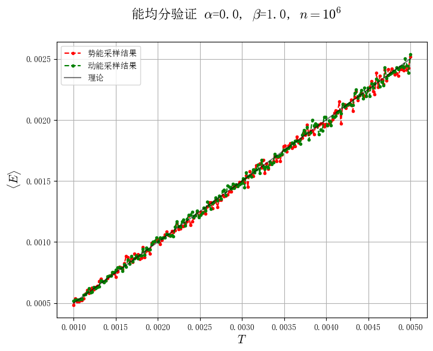

```python
fig, ax = plt.subplots(figsize=(8,6))
ax.plot(T_arr, VK_arr[:,0], "r--.", label="势能采样结果")
ax.plot(T_arr, VK_arr[:,1], "g--.", label="动能采样结果")
ax.plot(T_arr, 0.5 * T_arr, "k-", alpha=0.5, label="理论")
fit_y = k * T_arr + b
ax.grid()
ax.legend()
ax.set_xlabel("$T$")
ax.set_ylabel(r"$\langle E \rangle$")
fig.suptitle(f"能均分验证 $\\alpha$={alpha}, $\\beta$={beta}, $n=10^{np.log10(n_samples):.0f}$",fontsize=16)
display_inline(fig)
```

可见，在低温下仍旧有能均分，这和我们通过位力定理得到的结论相吻合.

## $k=1,\alpha=2,\beta=1$

下面我们加入 $\alpha$. 探究 $\alpha$ 对系统的影响.

### 相空间采样

取 $\alpha=2,\beta=1,T=1$，有

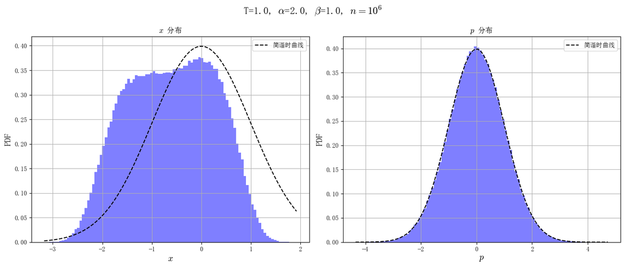

```python
T = 1.0
k = 1.0
alpha = 2.0
beta = 1.0

n_samples = int(1e6)
samples = metropolis_samples_full(T, k, alpha, beta, n_samples)

sigma_x = np.sqrt(T / k)
sigma_p = np.sqrt(T)
x_pdf = lambda x: (1.0 / (sigma_x * np.sqrt(2 * np.pi))) * np.exp(-0.5 * (x / sigma_x)**2)
p_pdf = lambda p: (1.0 / (sigma_p * np.sqrt(2 * np.pi))) * np.exp(-0.5 * (p / sigma_p)**2)

fig, axs = plt.subplots(1, 2, figsize=(14, 6))

axs[0].hist(samples[:, 0], color='blue', alpha=0.5, bins=100, density=True)
x_plt = np.linspace(np.min(samples[:, 0]), np.max(samples[:, 0]), 100)
axs[0].plot(x_plt, x_pdf(x_plt), "k--", label="简谐时曲线")
axs[0].set_title(r'$x$ 分布')
axs[0].set_xlabel(r'$x$')
axs[0].set_ylabel(r'PDF')
axs[0].legend()
axs[0].grid()

axs[1].hist(samples[:, 1], color='blue', alpha=0.5, bins=100, density=True)
p_plt = np.linspace(np.min(samples[:, 1]), np.max(samples[:, 1]), 100)
axs[1].plot(p_plt, p_pdf(p_plt), "k--", label="简谐时曲线")
axs[1].set_title(r'$p$ 分布')
axs[1].set_xlabel(r'$p$')
axs[1].set_ylabel(r'PDF')
axs[1].grid()
axs[1].legend()
fig.suptitle(f"T={T}, $\\alpha$={alpha}, $\\beta$={beta}, $n=10^{np.log10(n_samples):.0f}$",fontsize=16)
plt.tight_layout()
display_inline(fig)
```

可以看到，对于 $\alpha=2,\beta=1$ 的情况，其 $x$ 分布更宽，且在 $x=-1$ 附近出现一个平台.

但 $p$ 分布和简谐相同，这和我们前面的推导是吻合的，即改变势能形式，不会影响 $p$ 的分布.

上述性质可以在下面的热力图中体现.

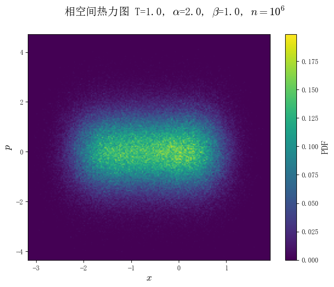

```python
def plot_heatmap(ax, x_data, y_data, bins=200):
    h, xedges, yedges = np.histogram2d(x_data, y_data, bins=bins, density=True)
    im = ax.imshow(h.T,
                   origin='lower',
                   extent=[xedges[0], xedges[-1], yedges[0], yedges[-1]],
                   aspect='auto',
                   cmap='viridis')
    plt.colorbar(im, ax=ax, label="PDF")
    return ax

fig, ax = plt.subplots(figsize=(8, 6))
plot_heatmap(ax, samples[:, 0], samples[:, 1])
fig.suptitle(f"相空间热力图 T={T}, $\\alpha$={alpha}, $\\beta$={beta}, $n=10^{np.log10(n_samples):.0f}$",fontsize=16)
ax.set_xlabel(r'$x$')
ax.set_ylabel(r'$p$')
display_inline(fig)
```

在 $x=-1$ 附近，由于 $V'(x) = k x + \alpha x^2 + \beta x^3$. 当 $k=\beta=1,\alpha=2$ 时，容易得到 $x=-1$ 是系统的一个驻点. 在附近其 $V$ 基本不变化，从而出现一个平台.

我们可以将 $V(x)$ 和 $x$ 分布画在同一张图中：

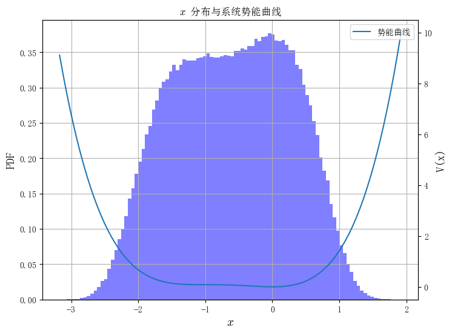

```python
fig, ax = plt.subplots(figsize=(8, 6))

ax.hist(samples[:, 0], color='blue', alpha=0.5, bins=100, density=True)
x_plt = np.linspace(np.min(samples[:, 0]), np.max(samples[:, 0]), 100)
#ax.plot(x_plt, x_pdf(x_plt), "k--", label="简谐时曲线")
ax.set_title(r'$x$ 分布与系统势能曲线')
ax.set_xlabel(r'$x$')
ax.set_ylabel(r'PDF')
#ax.legend()
ax.grid()

ax2 = ax.twinx()
ax2.plot(x_plt, 0.5*x_plt**2 + (2/3)*x_plt**3 + 0.25*x_plt**4, label="势能曲线")
ax2.set_ylabel(r"V(x)")
ax2.legend(loc=1)

display_inline(fig)
```

可见，在 $x=-1$ 处势能出现平台，$x$ 分布也因此出现平台.

### 热膨胀系数

下面我们来计算热膨胀系数.

```python
T_arr = np.linspace(0.001, 2, 200)
n_samples = int(1e6)
k = 1.0
alpha = 2.0
beta = 1.0

print("编译...")
_ = samples_T_arr(T_arr[:2], k, alpha, beta, n_samples)

print("开始采样...")
t_start = time.time()
samples_arr = samples_T_arr(T_arr, k, alpha, beta, n_samples)
print(f"结束，用时: {time.time() - t_start:.3f} s")
```

```
编译...
开始采样...
结束，用时: 4.337 s
```

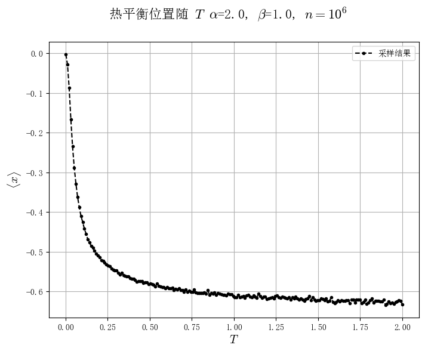

```python
x_avg = np.mean(samples_arr, axis=1)
fig, ax = plt.subplots(figsize=(8,6))
ax.plot(T_arr, x_avg, "k--.", label="采样结果")
ax.grid()
ax.legend()
ax.set_xlabel("$T$")
ax.set_ylabel(r"$\langle x \rangle$")
fig.suptitle(f"热平衡位置随 $T$ $\\alpha$={alpha}, $\\beta$={beta}, $n=10^{np.log10(n_samples):.0f}$",fontsize=16)
display_inline(fig)
```

可见平衡位置在一开始急剧下降，最后稳定在某个特定的值. 这里平衡位置下降的原因是很容易理解的. 因为当系统能量足够时，会有足够多的粒子“爬上”平台，从而导致平衡位置移动.

从图中我们知道，热平衡位置貌似最后会稳定在某个值. 这是需要进一步分析讨论的. 我们在后面的章节进行计算和验证.

从前面的推导中我们知道，在低温区，有：

$$ \langle x \rangle \approx - \frac{\alpha}{3 k_B T} \cdot 3 \left( \frac{k_B T}{k} \right)^2 = - \frac{\alpha k_B T}{k^2} $$

也就是，低温区的热膨胀系数理论上是 $-\frac{\alpha k_B}{k^2} = -2$. 下面我们来进行验证.

```python
T_arr = np.linspace(0.001, 0.005, 200)
n_samples = int(1e6)
k = 1.0
alpha = 2.0
beta = 1.0

print("编译...")
_ = samples_T_arr(T_arr[:2], k, alpha, beta, n_samples)

print("开始采样...")
t_start = time.time()
samples_arr = samples_T_arr(T_arr, k, alpha, beta, n_samples)
print(f"结束，用时: {time.time() - t_start:.3f} s")
```

```
编译...
开始采样...
结束，用时: 6.082 s
```

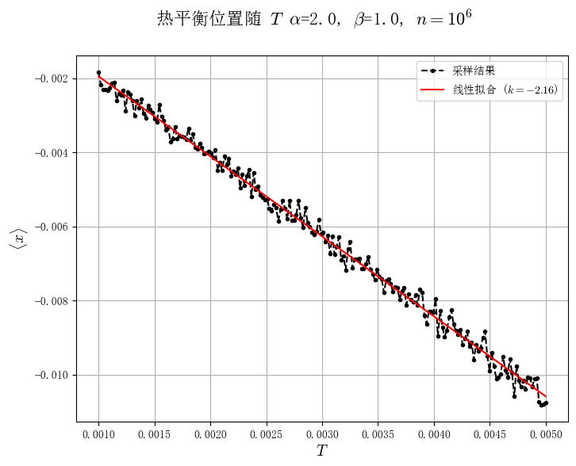

```python
x_avg = np.mean(samples_arr, axis=1)
k, b = np.polyfit(T_arr, x_avg, 1)
fit_y = k * T_arr + b

fig, ax = plt.subplots(figsize=(8,6))
ax.plot(T_arr, x_avg, "k--.", label="采样结果")
ax.plot(T_arr, fit_y, "r", label=f"线性拟合 ($k={k:.2f}$)")
ax.grid()
ax.legend()
ax.set_xlabel("$T$")
ax.set_ylabel(r"$\langle x \rangle$")
fig.suptitle(f"热平衡位置随 $T$ $\\alpha$={alpha}, $\\beta$={beta}, $n=10^{np.log10(n_samples):.0f}$",fontsize=16)
display_inline(fig)
```

可见，拟合斜率为 $k=-2.16$. 和我们的理论 $k=-2$ 接近.

### 热平衡位置高温下渐进行为

#### 微扰计算

温度较高时，粒子会出现在势能较高的位置，此时主要势能是 $\frac 1 4 \beta x^4$. 三次方项和二次方项此时可以当成微扰. 为了计算方便，我们忽略二次方项. （高温下其影响可以忽略）. 此时势能近似为：

$$V(x) \approx \frac{1}{3} \alpha x^3 + \frac{1}{4} \beta x^4$$

利用微扰展开： $$ \langle x \rangle \approx \frac{\int x \cdot [1 - \beta_{T}(\frac{1}{3}\alpha x^3)] e^{-\beta_{T} \frac{1}{4}\beta x^4} dx}{\int e^{-\beta_{T} \frac{1}{4}\beta x^4} dx} $$

分母记为配分函数 $Z$

分子计算易得：

$$ \text{分子} \approx - \frac{\alpha}{3 k_B T} \cdot \left( Z \cdot \langle x^4 \rangle_0 \right) = - \frac{\alpha}{3 k_B T} \cdot Z \cdot \left( \frac{k_B T}{\beta} \right) $$

最终得到高温下的热平衡位置：

$$ \langle x \rangle \approx - \frac{\alpha}{3 k_B T} \cdot \frac{k_B T}{\beta} = - \frac{\alpha}{3 \beta} $$

对于此系统，也就是 $\langle x \rangle \approx - \frac 2 3$

#### 数值验证

```python
T_arr = np.linspace(50, 100, 200)
n_samples = int(1e6)
k = 1.0
alpha = 2.0
beta = 1.0

print("编译...")
_ = samples_T_arr(T_arr[:2], k, alpha, beta, n_samples)

print("开始采样...")
t_start = time.time()
samples_arr = samples_T_arr(T_arr, k, alpha, beta, n_samples)
print(f"结束，用时: {time.time() - t_start:.3f} s")
```

```
编译...
开始采样...
结束，用时: 3.572 s
```

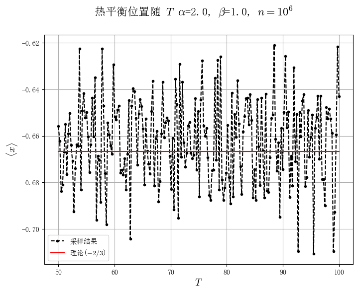

```python
x_avg = np.mean(samples_arr, axis=1)
fig, ax = plt.subplots(figsize=(8,6))
ax.plot(T_arr, x_avg, "k--.", label="采样结果")
ax.plot(T_arr,np.ones_like(T_arr)*(-2/3),"r-",label="理论($-2/3$)")
ax.grid()
ax.legend()
ax.set_xlabel("$T$")
ax.set_ylabel(r"$\langle x \rangle$")
fig.suptitle(f"热平衡位置随 $T$ $\\alpha$={alpha}, $\\beta$={beta}, $n=10^{np.log10(n_samples):.0f}$",fontsize=16)
display_inline(fig)
```

可见在温度极高的情况下，热平衡位置确实在 $-2/3$ 附近，且随着 $T$ 没有明显变化，和我们的微扰计算是相吻合的.

### 能均分

下面我们探索此系统是否出现能均分：

```python
T_arr = np.linspace(0.001, 2, 200)
n_samples = int(1e6)
k = 1.0
alpha = 2.0
beta = 1.0

print("编译...")
_ = calc_VK2(T_arr[:2], k, alpha, beta, n_samples)

print("开始采样...")
t_start = time.time()
VK_arr = calc_VK2(T_arr, k, alpha, beta, n_samples)
print(f"结束，用时: {time.time() - t_start:.3f} s")
```

```
编译...
开始采样...
结束，用时: 23.177 s
```

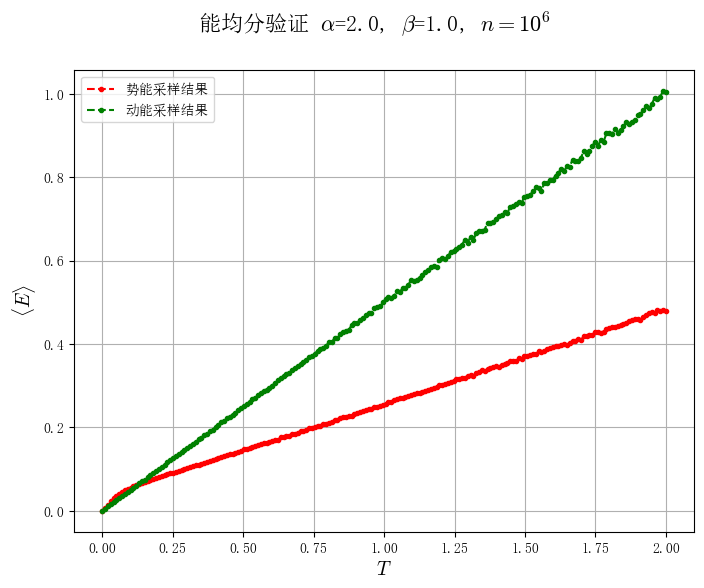

```python
fig, ax = plt.subplots(figsize=(8,6))
ax.plot(T_arr, VK_arr[:,0], "r--.", label="势能采样结果")
ax.plot(T_arr, VK_arr[:,1], "g--.", label="动能采样结果")
#ax.plot(T_arr, 0.5 * T_arr, "k-", alpha=0.5, label="理论")
fit_y = k * T_arr + b
ax.grid()
ax.legend()
ax.set_xlabel("$T$")
ax.set_ylabel(r"$\langle E \rangle$")
fig.suptitle(f"能均分验证 $\\alpha$={alpha}, $\\beta$={beta}, $n=10^{np.log10(n_samples):.0f}$",fontsize=16)
display_inline(fig)
```

和 $\alpha=0,\beta=1$ 的情况类似，在高温下，系统不再具有能均分的性质. 但对于低温区，有：

```python
T_arr = np.linspace(0.001, 0.005, 200)
n_samples = int(1e6)
k = 1.0
alpha = 2.0
beta = 1.0

print("编译...")
_ = calc_VK2(T_arr[:2], k, alpha, beta, n_samples)

print("开始采样...")
t_start = time.time()
VK_arr = calc_VK2(T_arr, k, alpha, beta, n_samples)
print(f"结束，用时: {time.time() - t_start:.3f} s")
```

```
编译...
开始采样...
结束，用时: 25.595 s
```

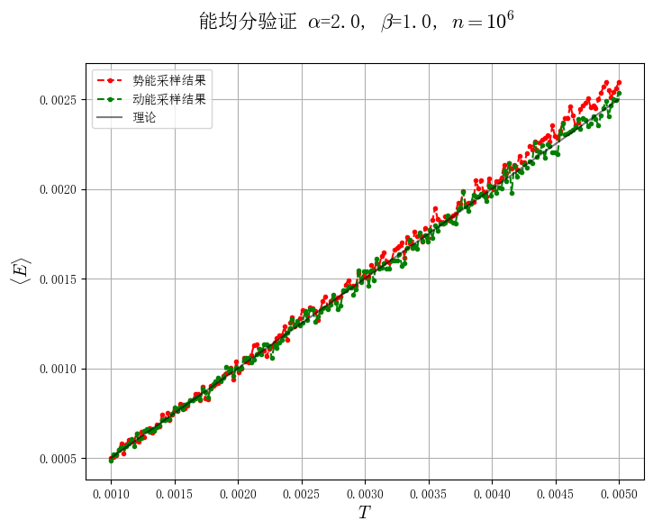

```python
fig, ax = plt.subplots(figsize=(8,6))
ax.plot(T_arr, VK_arr[:,0], "r--.", label="势能采样结果")
ax.plot(T_arr, VK_arr[:,1], "g--.", label="动能采样结果")
ax.plot(T_arr, 0.5 * T_arr, "k-", alpha=0.5, label="理论")
fit_y = k * T_arr + b
ax.grid()
ax.legend()
ax.set_xlabel("$T$")
ax.set_ylabel(r"$\langle E \rangle$")
fig.suptitle(f"能均分验证 $\\alpha$={alpha}, $\\beta$={beta}, $n=10^{np.log10(n_samples):.0f}$",fontsize=16)
display_inline(fig)
```

## 结论

对于简谐情况：

- 通过理论和 Metropolis 采样，得到了简谐情况的相空间的分布，并进行对比验证.
- 简谐时热膨胀系数为 $0$. 有能均分现象.

对于 $\alpha=0,\beta=1$：

- $p$ 分布和简谐相同，$x$ 分布相比简谐更“集中”在 $x=0$.
- 热膨胀系数为 $0$.
- 通过数值计算和位力定理，得到此系统低温仍有能均分现象，高温时动能势能分离.

对于 $\alpha=2,\beta=1$：

- $p$ 分布和简谐相同，$x$ 分布相比简谐更“分散”，在 $x=-1$ 处出现“平台”
- 出现负的热膨胀现象. 通过微扰计算和数值验证得到低温时热平衡位置满足： $$ \langle x \rangle \approx - \frac{\alpha k_B T}{k^2} $$ 热膨胀系数为 $-\alpha k_B/k^2$. 通过微扰计算和数值验证得到高温时系统热平衡位置基本不变，热平衡位置满足： $$ \langle x \rangle \approx - \frac{\alpha}{3 \beta} $$ 热膨胀系数为 $0$.
- 通过数值计算和位力定理，得到此系统低温仍有能均分现象，高温时动能势能分离. 且分离速度快于 $\alpha=0,\beta=1$ 的系统.

## 参考资料

- 刘川, 理论力学. §2.10 对称性与守恒律（位力定理相关内容）
- 部分积分公式推导使用 Google Gemini AI 辅助计算（经过检查）
- 部分代码编写时使用 Fitten Code AI 进行补全
- 代码实现中使用 Google Gemini AI 查询了一些函数的用法.

## 致谢

暂无

## 附一：问题

- 对于 Metropolis 采样，其只能得到平衡态. 无法得到非平衡态. 从概率论的角度其使用了马尔科夫链，也就是转移状态只与当前状态有关（无记忆性）. 这和非平衡的过程是不符合的. 那么如果修改使得具有某种记忆性（例如使用郎之万动力学等），可否得到计算非平衡态的方法？
- 在 $\alpha=2,\beta=1$ 的系统中，随着温度变化，势能平均相比动能平均是先大后小的，这个现象很有趣，但受限精力没有进一步探索并使用微扰方法尝试给出解释.

## 附二：学习心得

- Metropolis 采样
- 统计物理初步体验